# Data Quality Check Report

Insitute for Alpine Environment, Eurac Research

Report start at **2017-12-14 09:03:15**

### INPUT info:

File selected: **S3.dat**

You have also select these parameters:

- Data start from row: *5*
- The name of column is on row: *2*
- The datetime header is: *TIMESTAMP*
- The record header is: *RECORD*
- The datetime format is: *yyyy-mm-dd HH:MM*
- The sampling interval is: *15 min*

The folders are:

- Data folder: *H:/Projekte/Klimawandel/Experiment/data/2order/DataQualityCheckEuracAlpEnv/Data/Input/*
- Report folder: *H:/Projekte/Klimawandel/Experiment/data/2order/DataQualityCheckEuracAlpEnv/Report/*
- Output folder: *H:/Projekte/Klimawandel/Experiment/data/2order/DataQualityCheckEuracAlpEnv/Data/Output/*
- Support folder: *H:/Projekte/Klimawandel/Experiment/data/2order/DataQualityCheckEuracAlpEnv/Data/Support_files/*

Range file in support folder is called: *Range.csv*

You decide: *to write output file in output folder*

### OUTPUT:

#### Info empty file:

S3.dat has some obseravtion.

#### **Duplicated rows**

More details on: H:/Projekte/Klimawandel/Experiment/data/2order/DataQualityCheckEuracAlpEnv/Data/Output/Duplicated_S3.csv

#### **Overlap**

In S3.dat there isn’t any overlap!

#### **Missing dates**

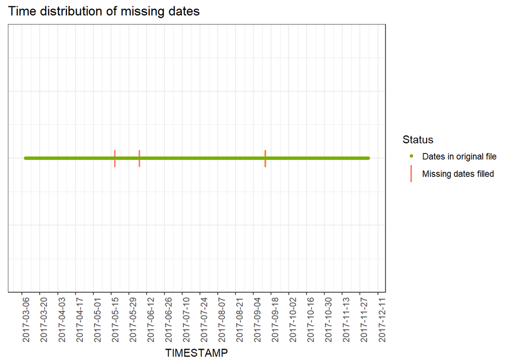

Statistics of missing dates:

| From | To | Number of Record |
| --- | --- | --- |
| 2017-05-18 00:15:00 | 2017-05-18 00:15:00 | 1 |
| 2017-06-06 11:30:00 | 2017-06-06 11:30:00 | 1 |
| 2017-09-13 10:15:00 | 2017-09-13 14:15:00 | 17 |

#### **Values out of admitted range**

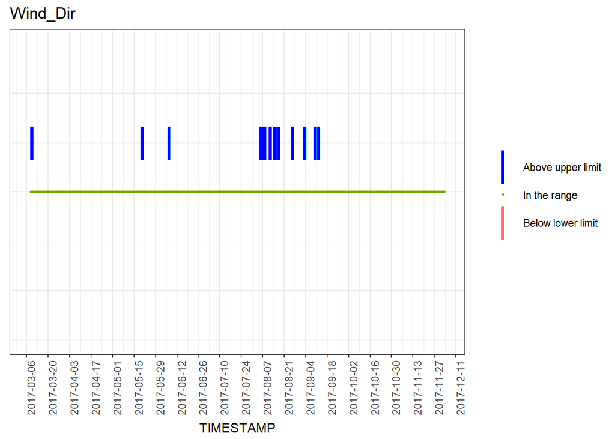

|  | From | To | Number of Record |
| --- | --- | --- | --- |
| Above upper limit | 2017-03-09 05:00:00 | 2017-03-09 11:00:00 | 25 |
| Above upper limit | 2017-05-20 02:15:00 | 2017-05-20 04:30:00 | 10 |
| Above upper limit | 2017-05-20 05:15:00 | 2017-05-20 05:15:00 | 1 |
| Above upper limit | 2017-05-20 07:15:00 | 2017-05-20 07:15:00 | 1 |
| Above upper limit | 2017-06-06 16:00:00 | 2017-06-06 16:15:00 | 2 |
| Above upper limit | 2017-08-05 10:15:00 | 2017-08-05 10:15:00 | 1 |
| Above upper limit | 2017-08-07 09:30:00 | 2017-08-07 09:30:00 | 1 |
| Above upper limit | 2017-08-08 10:15:00 | 2017-08-08 10:15:00 | 1 |
| Above upper limit | 2017-08-11 21:30:00 | 2017-08-11 21:30:00 | 1 |
| Above upper limit | 2017-08-11 23:00:00 | 2017-08-11 23:00:00 | 1 |
| Above upper limit | 2017-08-11 23:45:00 | 2017-08-11 23:45:00 | 1 |
| Above upper limit | 2017-08-14 10:15:00 | 2017-08-14 10:15:00 | 1 |
| Above upper limit | 2017-08-15 10:15:00 | 2017-08-15 10:15:00 | 1 |
| Above upper limit | 2017-08-17 09:15:00 | 2017-08-17 09:15:00 | 1 |
| Above upper limit | 2017-08-26 10:30:00 | 2017-08-26 10:30:00 | 1 |
| Above upper limit | 2017-09-03 03:00:00 | 2017-09-03 03:00:00 | 1 |
| Above upper limit | 2017-09-03 04:15:00 | 2017-09-03 04:15:00 | 1 |
| Above upper limit | 2017-09-03 04:45:00 | 2017-09-03 08:15:00 | 15 |
| Above upper limit | 2017-09-10 00:30:00 | 2017-09-10 00:30:00 | 1 |
| Above upper limit | 2017-09-10 02:15:00 | 2017-09-10 03:00:00 | 4 |
| Above upper limit | 2017-09-12 10:30:00 | 2017-09-12 11:15:00 | 4 |

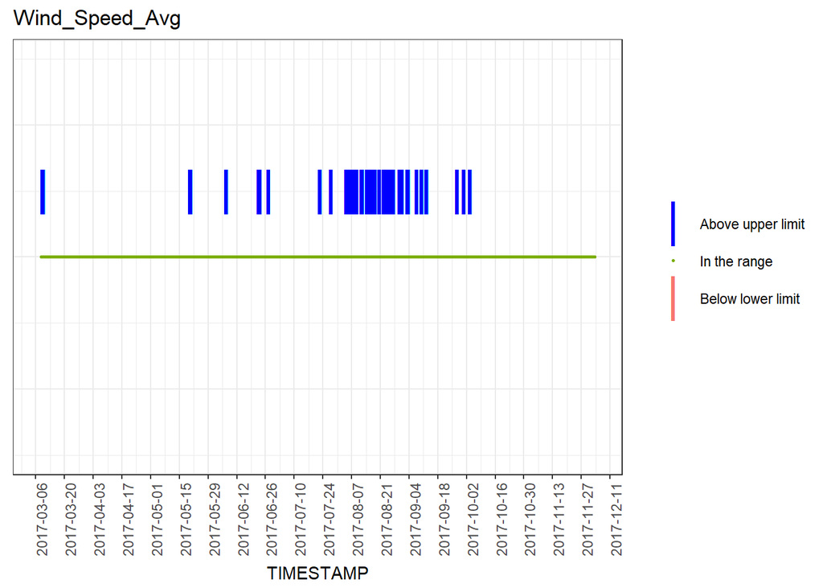

|  | From | To | Number of Record |
| --- | --- | --- | --- |
| Above upper limit | 2017-03-09 05:00:00 | 2017-03-09 11:30:00 | 27 |
| Above upper limit | 2017-05-20 01:30:00 | 2017-05-20 01:30:00 | 1 |
| Above upper limit | 2017-05-20 02:00:00 | 2017-05-20 05:30:00 | 15 |
| Above upper limit | 2017-05-20 07:15:00 | 2017-05-20 07:30:00 | 2 |
| Above upper limit | 2017-06-06 16:00:00 | 2017-06-06 16:30:00 | 3 |
| Above upper limit | 2017-06-22 14:30:00 | 2017-06-22 14:30:00 | 1 |
| Above upper limit | 2017-06-23 06:30:00 | 2017-06-23 06:30:00 | 1 |
| Above upper limit | 2017-06-27 12:00:00 | 2017-06-27 12:00:00 | 1 |
| Above upper limit | 2017-07-22 10:00:00 | 2017-07-22 10:30:00 | 3 |
| Above upper limit | 2017-07-27 20:00:00 | 2017-07-27 20:00:00 | 1 |
| Above upper limit | 2017-08-04 09:45:00 | 2017-08-04 09:45:00 | 1 |
| Above upper limit | 2017-08-04 11:15:00 | 2017-08-04 11:15:00 | 1 |
| Above upper limit | 2017-08-05 10:15:00 | 2017-08-05 10:15:00 | 1 |
| Above upper limit | 2017-08-05 10:45:00 | 2017-08-05 11:00:00 | 2 |
| Above upper limit | 2017-08-06 07:00:00 | 2017-08-06 07:00:00 | 1 |
| Above upper limit | 2017-08-07 09:00:00 | 2017-08-07 09:00:00 | 1 |
| Above upper limit | 2017-08-07 09:30:00 | 2017-08-07 10:00:00 | 3 |
| Above upper limit | 2017-08-07 10:30:00 | 2017-08-07 10:30:00 | 1 |
| Above upper limit | 2017-08-08 08:45:00 | 2017-08-08 08:45:00 | 1 |
| Above upper limit | 2017-08-08 09:45:00 | 2017-08-08 09:45:00 | 1 |
| Above upper limit | 2017-08-08 10:15:00 | 2017-08-08 10:15:00 | 1 |
| Above upper limit | 2017-08-09 09:45:00 | 2017-08-09 09:45:00 | 1 |
| Above upper limit | 2017-08-11 21:30:00 | 2017-08-11 21:45:00 | 2 |
| Above upper limit | 2017-08-11 23:00:00 | 2017-08-12 00:15:00 | 6 |
| Above upper limit | 2017-08-12 00:45:00 | 2017-08-12 00:45:00 | 1 |
| Above upper limit | 2017-08-14 10:00:00 | 2017-08-14 10:30:00 | 3 |
| Above upper limit | 2017-08-14 11:00:00 | 2017-08-14 11:00:00 | 1 |
| Above upper limit | 2017-08-14 13:15:00 | 2017-08-14 13:15:00 | 1 |
| Above upper limit | 2017-08-15 10:00:00 | 2017-08-15 10:15:00 | 2 |
| Above upper limit | 2017-08-15 11:15:00 | 2017-08-15 11:15:00 | 1 |
| Above upper limit | 2017-08-16 10:00:00 | 2017-08-16 10:00:00 | 1 |
| Above upper limit | 2017-08-16 11:15:00 | 2017-08-16 11:15:00 | 1 |
| Above upper limit | 2017-08-16 13:30:00 | 2017-08-16 13:30:00 | 1 |
| Above upper limit | 2017-08-16 15:30:00 | 2017-08-16 15:30:00 | 1 |
| Above upper limit | 2017-08-17 07:15:00 | 2017-08-17 07:15:00 | 1 |
| Above upper limit | 2017-08-17 09:15:00 | 2017-08-17 09:15:00 | 1 |
| Above upper limit | 2017-08-17 14:30:00 | 2017-08-17 14:30:00 | 1 |
| Above upper limit | 2017-08-18 09:00:00 | 2017-08-18 09:00:00 | 1 |
| Above upper limit | 2017-08-18 09:30:00 | 2017-08-18 09:30:00 | 1 |
| Above upper limit | 2017-08-20 09:00:00 | 2017-08-20 09:00:00 | 1 |
| Above upper limit | 2017-08-22 10:45:00 | 2017-08-22 10:45:00 | 1 |
| Above upper limit | 2017-08-23 09:00:00 | 2017-08-23 09:15:00 | 2 |
| Above upper limit | 2017-08-23 16:00:00 | 2017-08-23 16:00:00 | 1 |
| Above upper limit | 2017-08-24 09:30:00 | 2017-08-24 09:45:00 | 2 |
| Above upper limit | 2017-08-24 11:00:00 | 2017-08-24 11:00:00 | 1 |
| Above upper limit | 2017-08-25 07:30:00 | 2017-08-25 07:45:00 | 2 |
| Above upper limit | 2017-08-25 09:15:00 | 2017-08-25 09:30:00 | 2 |
| Above upper limit | 2017-08-25 10:00:00 | 2017-08-25 10:15:00 | 2 |
| Above upper limit | 2017-08-25 18:30:00 | 2017-08-25 18:30:00 | 1 |
| Above upper limit | 2017-08-26 10:15:00 | 2017-08-26 10:30:00 | 2 |
| Above upper limit | 2017-08-27 07:30:00 | 2017-08-27 07:45:00 | 2 |
| Above upper limit | 2017-08-30 09:45:00 | 2017-08-30 10:00:00 | 2 |
| Above upper limit | 2017-08-30 17:45:00 | 2017-08-30 18:15:00 | 3 |
| Above upper limit | 2017-08-31 09:45:00 | 2017-08-31 09:45:00 | 1 |
| Above upper limit | 2017-08-31 10:15:00 | 2017-08-31 10:15:00 | 1 |
| Above upper limit | 2017-09-03 01:15:00 | 2017-09-03 01:15:00 | 1 |
| Above upper limit | 2017-09-03 02:30:00 | 2017-09-03 03:15:00 | 4 |
| Above upper limit | 2017-09-03 04:15:00 | 2017-09-03 08:30:00 | 18 |
| Above upper limit | 2017-09-07 14:15:00 | 2017-09-07 14:15:00 | 1 |
| Above upper limit | 2017-09-10 00:00:00 | 2017-09-10 00:00:00 | 1 |
| Above upper limit | 2017-09-10 00:30:00 | 2017-09-10 00:45:00 | 2 |
| Above upper limit | 2017-09-10 02:00:00 | 2017-09-10 03:15:00 | 6 |
| Above upper limit | 2017-09-12 10:30:00 | 2017-09-12 11:30:00 | 5 |
| Above upper limit | 2017-09-27 11:00:00 | 2017-09-27 11:00:00 | 1 |
| Above upper limit | 2017-09-30 11:45:00 | 2017-09-30 11:45:00 | 1 |
| Above upper limit | 2017-10-03 12:15:00 | 2017-10-03 12:30:00 | 2 |

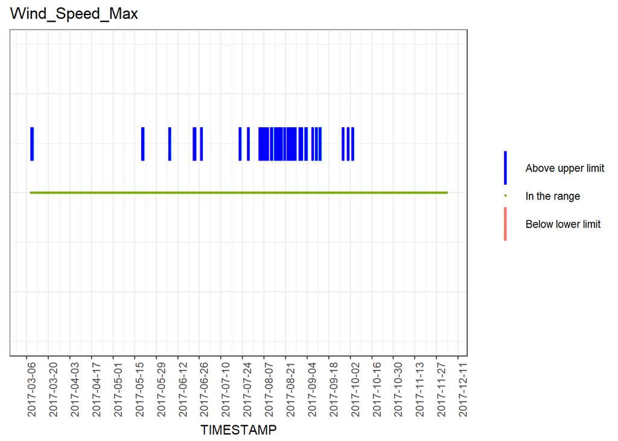

|  | From | To | Number of Record |
| --- | --- | --- | --- |
| Above upper limit | 2017-03-09 05:00:00 | 2017-03-09 11:30:00 | 27 |
| Above upper limit | 2017-05-20 01:30:00 | 2017-05-20 01:30:00 | 1 |
| Above upper limit | 2017-05-20 02:00:00 | 2017-05-20 05:30:00 | 15 |
| Above upper limit | 2017-05-20 07:15:00 | 2017-05-20 07:30:00 | 2 |
| Above upper limit | 2017-06-06 16:00:00 | 2017-06-06 16:30:00 | 3 |
| Above upper limit | 2017-06-22 14:30:00 | 2017-06-22 14:30:00 | 1 |
| Above upper limit | 2017-06-23 06:30:00 | 2017-06-23 06:30:00 | 1 |
| Above upper limit | 2017-06-27 12:00:00 | 2017-06-27 12:00:00 | 1 |
| Above upper limit | 2017-07-22 10:00:00 | 2017-07-22 10:30:00 | 3 |
| Above upper limit | 2017-07-27 20:00:00 | 2017-07-27 20:00:00 | 1 |
| Above upper limit | 2017-08-04 09:45:00 | 2017-08-04 09:45:00 | 1 |
| Above upper limit | 2017-08-04 11:15:00 | 2017-08-04 11:15:00 | 1 |
| Above upper limit | 2017-08-05 10:15:00 | 2017-08-05 10:15:00 | 1 |
| Above upper limit | 2017-08-05 10:45:00 | 2017-08-05 11:00:00 | 2 |
| Above upper limit | 2017-08-06 07:00:00 | 2017-08-06 07:00:00 | 1 |
| Above upper limit | 2017-08-07 09:00:00 | 2017-08-07 09:00:00 | 1 |
| Above upper limit | 2017-08-07 09:30:00 | 2017-08-07 10:00:00 | 3 |
| Above upper limit | 2017-08-07 10:30:00 | 2017-08-07 10:30:00 | 1 |
| Above upper limit | 2017-08-08 08:45:00 | 2017-08-08 08:45:00 | 1 |
| Above upper limit | 2017-08-08 09:45:00 | 2017-08-08 09:45:00 | 1 |
| Above upper limit | 2017-08-08 10:15:00 | 2017-08-08 10:15:00 | 1 |
| Above upper limit | 2017-08-09 09:45:00 | 2017-08-09 09:45:00 | 1 |
| Above upper limit | 2017-08-11 21:30:00 | 2017-08-11 21:45:00 | 2 |
| Above upper limit | 2017-08-11 23:00:00 | 2017-08-12 00:15:00 | 6 |
| Above upper limit | 2017-08-12 00:45:00 | 2017-08-12 00:45:00 | 1 |
| Above upper limit | 2017-08-14 10:00:00 | 2017-08-14 10:30:00 | 3 |
| Above upper limit | 2017-08-14 11:00:00 | 2017-08-14 11:00:00 | 1 |
| Above upper limit | 2017-08-14 13:15:00 | 2017-08-14 13:15:00 | 1 |
| Above upper limit | 2017-08-15 10:00:00 | 2017-08-15 10:15:00 | 2 |
| Above upper limit | 2017-08-15 11:15:00 | 2017-08-15 11:15:00 | 1 |
| Above upper limit | 2017-08-16 10:00:00 | 2017-08-16 10:00:00 | 1 |
| Above upper limit | 2017-08-16 11:15:00 | 2017-08-16 11:15:00 | 1 |
| Above upper limit | 2017-08-16 13:30:00 | 2017-08-16 13:30:00 | 1 |
| Above upper limit | 2017-08-16 15:30:00 | 2017-08-16 15:30:00 | 1 |
| Above upper limit | 2017-08-17 07:15:00 | 2017-08-17 07:15:00 | 1 |
| Above upper limit | 2017-08-17 09:15:00 | 2017-08-17 09:15:00 | 1 |
| Above upper limit | 2017-08-17 14:30:00 | 2017-08-17 14:30:00 | 1 |
| Above upper limit | 2017-08-18 09:00:00 | 2017-08-18 09:00:00 | 1 |
| Above upper limit | 2017-08-18 09:30:00 | 2017-08-18 09:30:00 | 1 |
| Above upper limit | 2017-08-20 09:00:00 | 2017-08-20 09:00:00 | 1 |
| Above upper limit | 2017-08-22 10:45:00 | 2017-08-22 10:45:00 | 1 |
| Above upper limit | 2017-08-23 09:00:00 | 2017-08-23 09:15:00 | 2 |
| Above upper limit | 2017-08-23 16:00:00 | 2017-08-23 16:00:00 | 1 |
| Above upper limit | 2017-08-24 09:30:00 | 2017-08-24 09:45:00 | 2 |
| Above upper limit | 2017-08-24 11:00:00 | 2017-08-24 11:00:00 | 1 |
| Above upper limit | 2017-08-25 07:30:00 | 2017-08-25 07:45:00 | 2 |
| Above upper limit | 2017-08-25 09:15:00 | 2017-08-25 09:30:00 | 2 |
| Above upper limit | 2017-08-25 10:00:00 | 2017-08-25 10:15:00 | 2 |
| Above upper limit | 2017-08-25 18:30:00 | 2017-08-25 18:30:00 | 1 |
| Above upper limit | 2017-08-26 10:15:00 | 2017-08-26 10:30:00 | 2 |
| Above upper limit | 2017-08-27 07:30:00 | 2017-08-27 07:45:00 | 2 |
| Above upper limit | 2017-08-30 09:45:00 | 2017-08-30 10:00:00 | 2 |
| Above upper limit | 2017-08-30 17:45:00 | 2017-08-30 18:15:00 | 3 |
| Above upper limit | 2017-08-31 09:45:00 | 2017-08-31 09:45:00 | 1 |
| Above upper limit | 2017-08-31 10:15:00 | 2017-08-31 10:15:00 | 1 |
| Above upper limit | 2017-09-03 01:15:00 | 2017-09-03 01:15:00 | 1 |
| Above upper limit | 2017-09-03 02:30:00 | 2017-09-03 03:15:00 | 4 |
| Above upper limit | 2017-09-03 04:15:00 | 2017-09-03 08:30:00 | 18 |
| Above upper limit | 2017-09-07 14:15:00 | 2017-09-07 14:15:00 | 1 |
| Above upper limit | 2017-09-10 00:00:00 | 2017-09-10 00:00:00 | 1 |
| Above upper limit | 2017-09-10 00:30:00 | 2017-09-10 00:45:00 | 2 |
| Above upper limit | 2017-09-10 02:00:00 | 2017-09-10 03:15:00 | 6 |
| Above upper limit | 2017-09-12 10:30:00 | 2017-09-12 11:30:00 | 5 |
| Above upper limit | 2017-09-27 11:00:00 | 2017-09-27 11:00:00 | 1 |
| Above upper limit | 2017-09-30 11:45:00 | 2017-09-30 11:45:00 | 1 |
| Above upper limit | 2017-10-03 12:15:00 | 2017-10-03 12:30:00 | 2 |

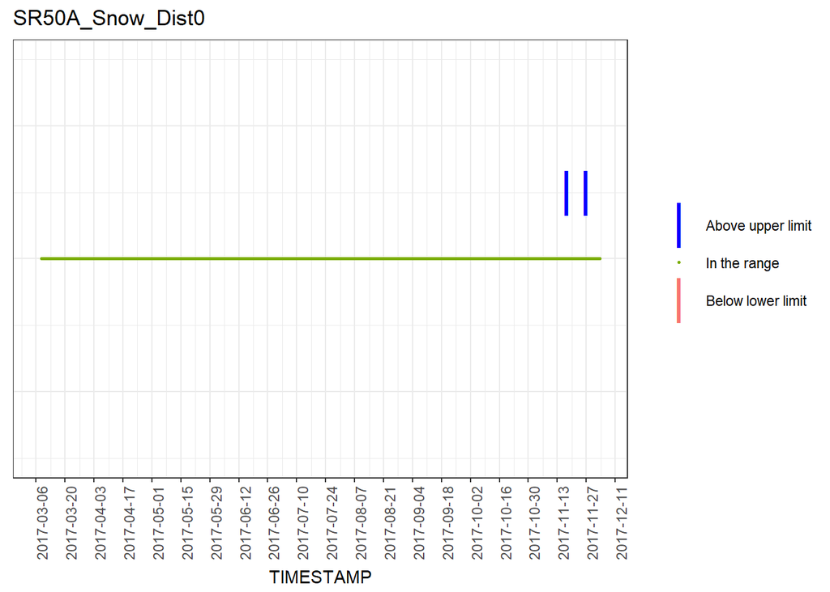

|  | From | To | Number of Record |
| --- | --- | --- | --- |
| Above upper limit | 2017-11-17 05:45:00 | 2017-11-17 05:45:00 | 1 |
| Above upper limit | 2017-11-26 16:00:00 | 2017-11-26 16:00:00 | 1 |

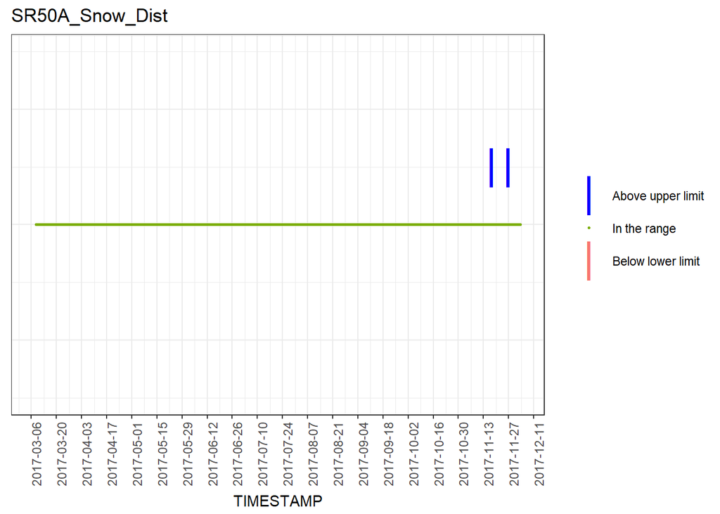

|  | From | To | Number of Record |
| --- | --- | --- | --- |
| Above upper limit | 2017-11-17 05:45:00 | 2017-11-17 05:45:00 | 1 |
| Above upper limit | 2017-11-26 16:00:00 | 2017-11-26 16:00:00 | 1 |

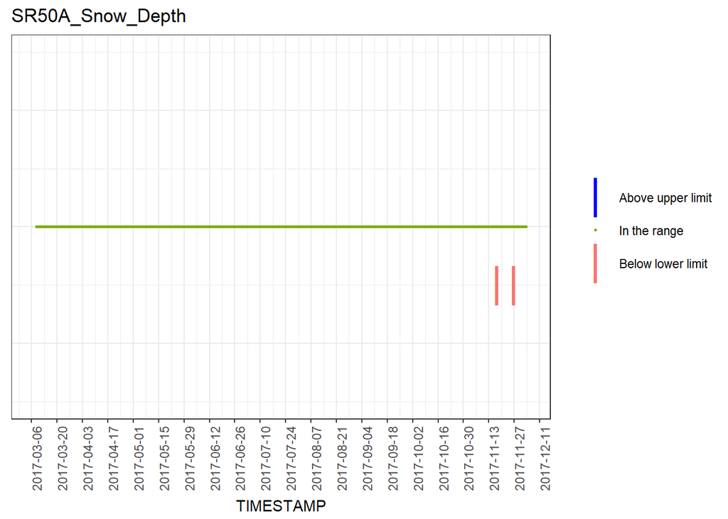

|  | From | To | Number of Record |
| --- | --- | --- | --- |
| Under lower limit | 2017-11-17 05:45:00 | 2017-11-17 05:45:00 | 1 |
| Under lower limit | 2017-11-26 16:00:00 | 2017-11-26 16:00:00 | 1 |

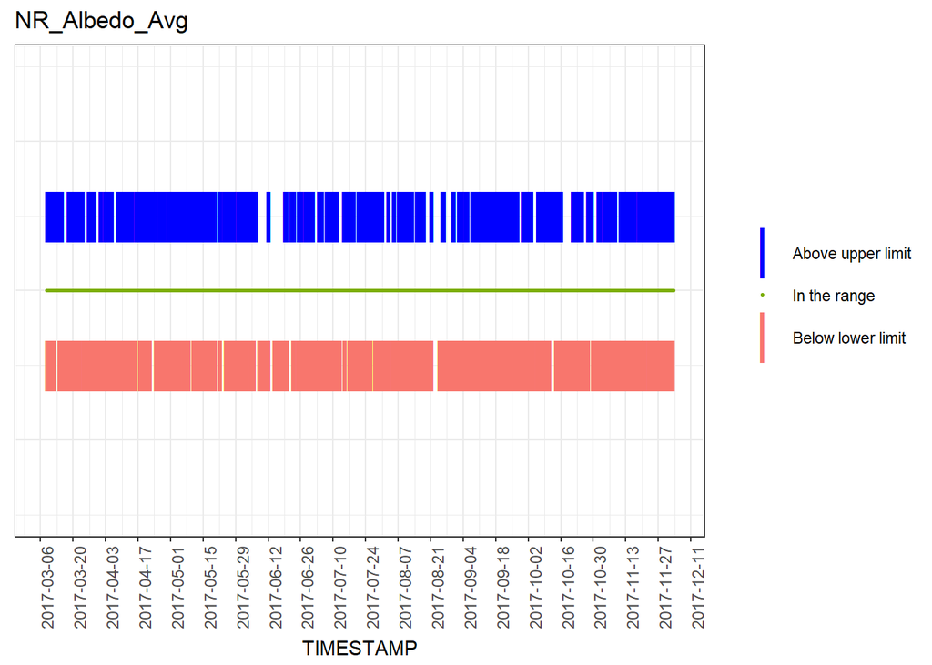

|  | From | To | Number of Record |
| --- | --- | --- | --- |
| Above upper limit | 2017-03-08 20:15:00 | 2017-03-08 20:15:00 | 1 |
| Under lower limit | 2017-03-08 20:45:00 | 2017-03-08 20:45:00 | 1 |
| Above upper limit | 2017-03-08 21:00:00 | 2017-03-08 21:00:00 | 1 |
| Under lower limit | 2017-03-09 00:00:00 | 2017-03-09 00:00:00 | 1 |
| Above upper limit | 2017-03-09 06:45:00 | 2017-03-09 18:45:00 | 49 |
| Under lower limit | 2017-03-09 21:00:00 | 2017-03-09 21:00:00 | 1 |
| Above upper limit | 2017-03-09 21:15:00 | 2017-03-09 21:15:00 | 1 |
| Under lower limit | 2017-03-09 23:00:00 | 2017-03-09 23:45:00 | 4 |
| Under lower limit | 2017-03-10 00:30:00 | 2017-03-10 00:30:00 | 1 |
| Under lower limit | 2017-03-10 01:15:00 | 2017-03-10 01:30:00 | 2 |
| Under lower limit | 2017-03-10 02:45:00 | 2017-03-10 02:45:00 | 1 |
| Under lower limit | 2017-03-10 06:30:00 | 2017-03-10 06:30:00 | 1 |
| Above upper limit | 2017-03-10 06:45:00 | 2017-03-10 06:45:00 | 1 |
| Above upper limit | 2017-03-10 18:30:00 | 2017-03-10 18:30:00 | 1 |
| Above upper limit | 2017-03-11 06:45:00 | 2017-03-11 06:45:00 | 1 |
| Under lower limit | 2017-03-11 18:30:00 | 2017-03-11 18:30:00 | 1 |
| Above upper limit | 2017-03-12 06:45:00 | 2017-03-12 06:45:00 | 1 |
| Above upper limit | 2017-03-13 18:30:00 | 2017-03-13 18:30:00 | 1 |
| Under lower limit | 2017-03-14 06:30:00 | 2017-03-14 06:30:00 | 1 |
| Above upper limit | 2017-03-14 06:45:00 | 2017-03-14 06:45:00 | 1 |
| Under lower limit | 2017-03-14 18:30:00 | 2017-03-14 18:30:00 | 1 |
| Above upper limit | 2017-03-15 06:30:00 | 2017-03-15 06:45:00 | 2 |
| Under lower limit | 2017-03-16 03:45:00 | 2017-03-16 03:45:00 | 1 |
| Under lower limit | 2017-03-16 18:45:00 | 2017-03-16 18:45:00 | 1 |
| Under lower limit | 2017-03-17 06:30:00 | 2017-03-17 06:30:00 | 1 |
| Under lower limit | 2017-03-17 18:30:00 | 2017-03-17 18:30:00 | 1 |
| Above upper limit | 2017-03-18 06:30:00 | 2017-03-18 06:30:00 | 1 |
| Under lower limit | 2017-03-18 19:00:00 | 2017-03-18 19:30:00 | 3 |
| Under lower limit | 2017-03-18 20:45:00 | 2017-03-18 20:45:00 | 1 |
| Above upper limit | 2017-03-18 21:30:00 | 2017-03-18 21:30:00 | 1 |

[output cut: 1196 more lines]

Report end at **2017-12-14 09:04:31**